# Forecasting Monthly Air Quality Index for Cincinnati (Part-2)

- Show All Code
- Hide All Code
- View Source

Author

Cariappa K S

Published

February 1, 2023

#### Section 1. Checking the behavior/ data-generating process of the “Air Quality Index Dataset for Cincinnati”

```r
library(readxl)
library(tidyverse)
library(lubridate)
library(ggplot2)
library(zoo)
library(tsibble)
library(feasts) #to enable autoplots on tsibble
library(fable)
#library(forecast)

#setting up local working directory and loading dataset
setwd('D:/1Spring/BANA 7050 Forecasting')
AQIdata <- as.data.frame(read_excel('AQI Cincinnati 01252023.xlsx',sheet = "AQI"))
AQIdata <- AQIdata[,c('Date','AQI Value')]
colnames(AQIdata) <- c('Date','AQI')

#Creating a tsibble object at monthly granularity
AQIdata2<-AQIdata %>% filter(Date>="2017-01-01" & Date<="2022-12-31") %>%
  mutate(YM = yearmonth(Date,format = "%Y-%m-%d")) %>%
  group_by(YM) %>%
  summarize(value = mean(AQI)) %>%
  arrange(YM) %>%
  as_tsibble(index = YM)
```

### Additive Classical Decomposition

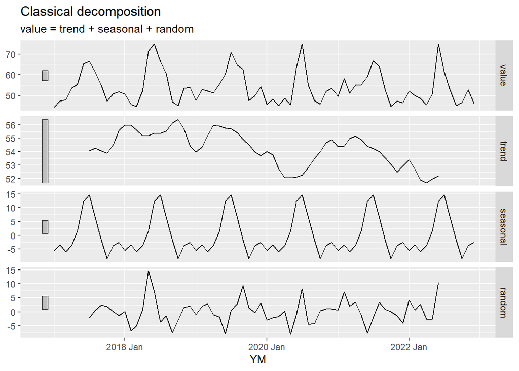

```r
AQIdata2_decomp <- AQIdata2 %>%
  model(
    classical_decomposition(value,type = 'additive')
  ) %>%
  components()

AQIdata2_decomp %>% autoplot()
```

##### Checking for stationarity using rolling calculations and statistical tests

1. We observe variance stationarity and therefore dont need to transform our time-series using log/ Box-Cox transformation

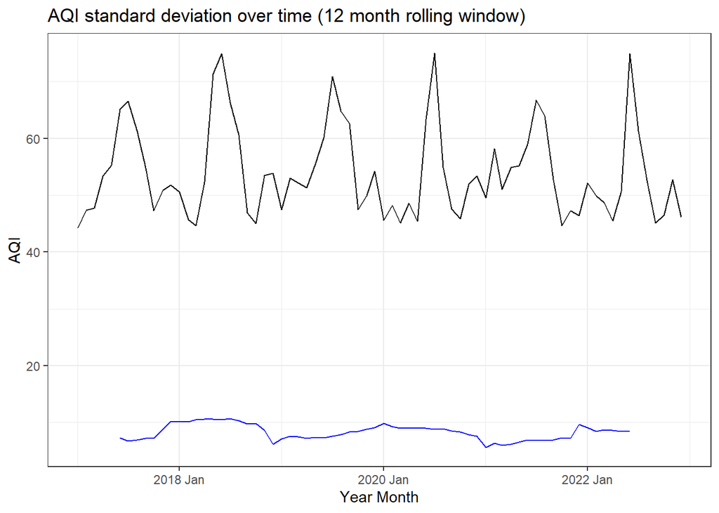

```r
AQIdata2_roll <- AQIdata2 %>%
  mutate(
      value_sd = zoo::rollapply(value,
      FUN = sd,
      width = 12,
      fill = NA))

AQIdata2_rollmean <- AQIdata2_roll %>%
  ggplot() +
    geom_line(aes(YM, value)) +
  geom_line(aes(YM, value_sd),color='blue') +
  theme_bw() +
  ggtitle("AQI standard deviation over time (12 month rolling window)") +
  ylab("AQI") +
  xlab("Year Month")

AQIdata2_rollmean
```

2. Performing seasonal differencing for our monthly data by taking 12 month lag difference
   $$Z_{T} - Z_{t-12}$$

```r
# performing seasonal differencing
AQIdata2 <- AQIdata2 %>% mutate(value_sdiff = value - lag(value,n = 12))
```

3(i). We observe mean stationarity and therefore don’t need to take first lag difference

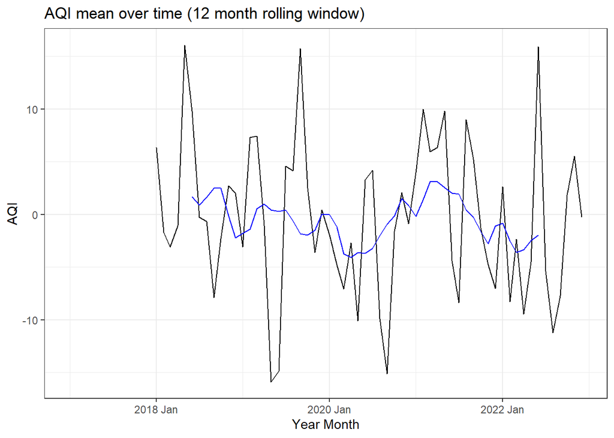

```r
AQIdata2_roll <- AQIdata2 %>%
  mutate(
    value_mean = zoo::rollmean(
      value_sdiff,
      k = 12,
      fill = NA))

AQIdata2_rollmean <- AQIdata2_roll %>%
  ggplot() +
    geom_line(aes(YM, value_sdiff)) +
  geom_line(aes(YM, value_mean),color='blue') +
  theme_bw() +
  ggtitle("AQI mean over time (12 month rolling window)") +
  ylab("AQI") +
  xlab("Year Month")

AQIdata2_rollmean
```

3 (ii). KPSS test confirms it is mean stationary as p value is greater than 0.05

```r
raw_value_kpss = AQIdata2 %>%
features(value_sdiff, unitroot_kpss)
raw_value_kpss
```

```
# A tibble: 1 × 2
  kpss_stat kpss_pvalue
      <dbl>       <dbl>
1     0.111         0.1
```

#### Section 2. Checking ACF/PACF of the transformed(stationary) time series

The time series appears to be an autoregressive process of order 2 as ACF plot is gradually decreasing and PACF plot has 2 significant lags, therefore we suspect the time-series to be of the order ARIMA(p,d,q) = (2,0,0).

The seasonal component - D is 1 as we have taken one difference to remove seasonality, the seasonal autoregressive and seasonal MA would be 0.

**ACF of transformed AQI**

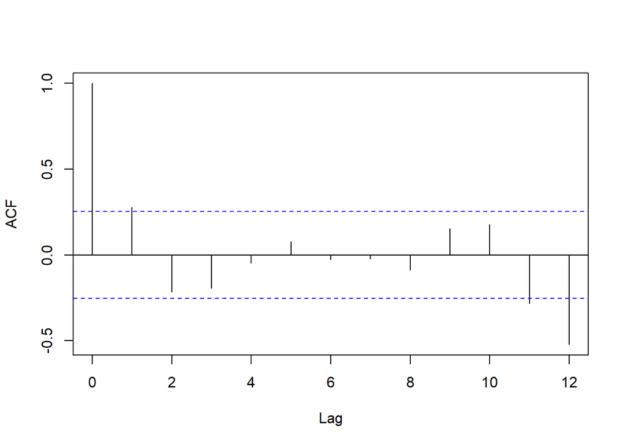

```r
acf(AQIdata2 %>% drop_na() %>% .$value_sdiff,lag.max=12,main='')
```

**PACF of transformed AQI**

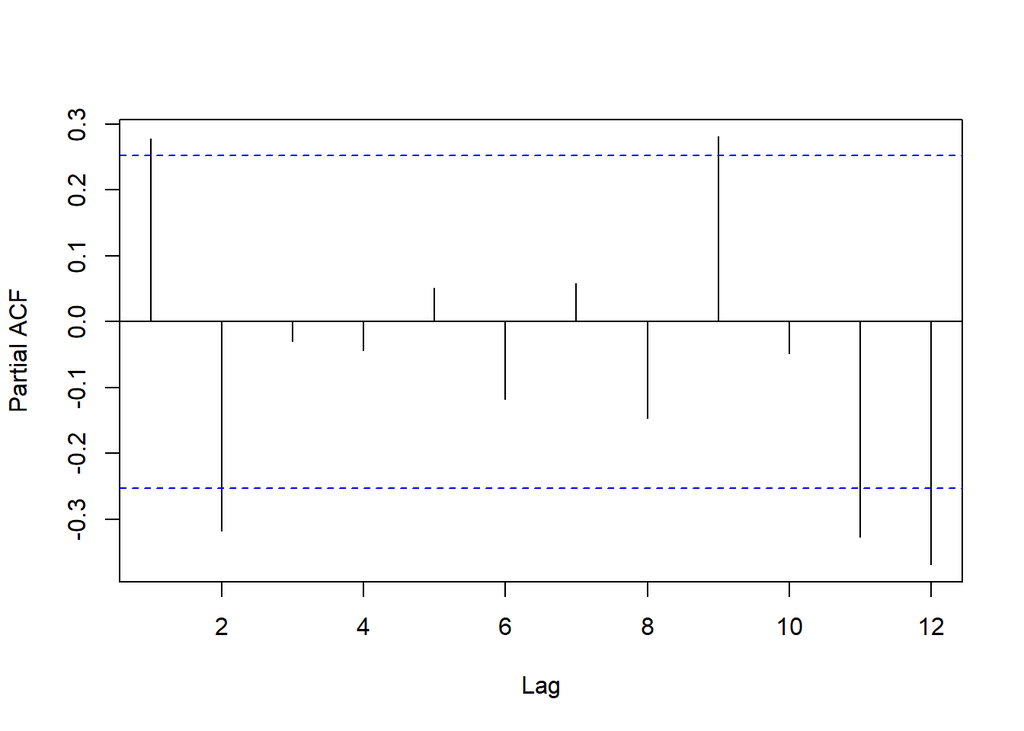

```r
pacf(AQIdata2 %>% drop_na() %>% .$value_sdiff,lag.max=12,main='')
```

#### Section 3. Selecting best ARIMA model according to BIC

Best model is ARIMA(2,0,0)+(0,1,0) according to BIC

```r
# Order = p,d,q (AR, I, MA)
models_bic = AQIdata2 %>%
  model(
    mod1 = ARIMA(value~pdq(1,0,0)+PDQ(0,1,0)),
    mod2 = ARIMA(value~pdq(1,1,1)+PDQ(0,1,0)),
    mod3 = ARIMA(value~pdq(1,1,0)+PDQ(0,1,0)),
    mod4 = ARIMA(value~pdq(2,1,0)+PDQ(0,1,0)),
    mod5 = ARIMA(value~pdq(2,1,1)+PDQ(0,1,0)),
    mod6 = ARIMA(value~pdq(2,0,0)+PDQ(0,1,0)),
    mod7 = ARIMA(value~pdq(2,0,0)+PDQ(0,0,0)),
    mod8 = ARIMA(value~pdq(2,1,0)+PDQ(0,0,0)),
    mod9 = ARIMA(value~pdq(2,0,1)+PDQ(0,1,0)),
    mod10 = ARIMA(value~pdq(3,0,0)+PDQ(0,1,0))
    )


models_bic%>%
  glance() %>%
  arrange(BIC)
```

```
# A tibble: 10 × 8
   .model sigma2 log_lik   AIC  AICc   BIC ar_roots  ma_roots
   <chr>   <dbl>   <dbl> <dbl> <dbl> <dbl> <list>    <list>
 1 mod6     45.2   -199.  403.  404.  410. <cpl [2]> <cpl [0]>
 2 mod5     46.8   -198.  403.  404.  412. <cpl [2]> <cpl [1]>
 3 mod1     49.7   -202.  408.  408.  412. <cpl [1]> <cpl [0]>
 4 mod2     51.4   -201.  407.  408.  414. <cpl [1]> <cpl [1]>
 5 mod9     46.0   -199.  405.  406.  414. <cpl [2]> <cpl [1]>
 6 mod10    46.0   -199.  405.  406.  414. <cpl [3]> <cpl [0]>
 7 mod4     65.7   -206.  419.  419.  425. <cpl [2]> <cpl [0]>
 8 mod3     76.6   -211.  426.  427.  431. <cpl [1]> <cpl [0]>
 9 mod7     41.4   -235.  478.  479.  487. <cpl [2]> <cpl [0]>
10 mod8     57.5   -244.  493.  494.  500. <cpl [2]> <cpl [0]>
```

The in-sample predicted value tends to follow the original time series trend with difference in scale

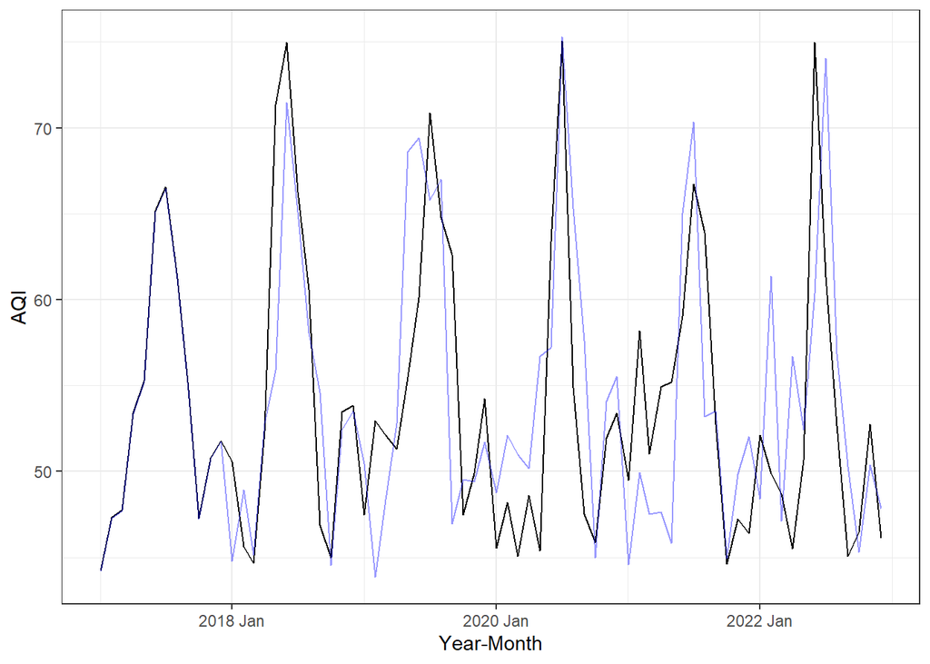

```r
best_mod = AQIdata2 %>%
  model(ARIMA(value~pdq(2,0,0)+PDQ(0,1,0),approximation = F, stepwise = F))

# Get fitted values
fitted = best_mod %>%
  augment() %>%
  .$.fitted

ggplot() +
  geom_line(aes(AQIdata2$YM, AQIdata2$value)) +
  geom_line(aes(AQIdata2$YM, fitted), color = "blue", alpha = 0.4) +
  theme_bw() +
  xlab("Year-Month") +
  ylab("AQI")
```

#### Section 4. Analyze the residuals

(i). The residual ACF plot indicates there is a significant residual lag present and its not white noise.

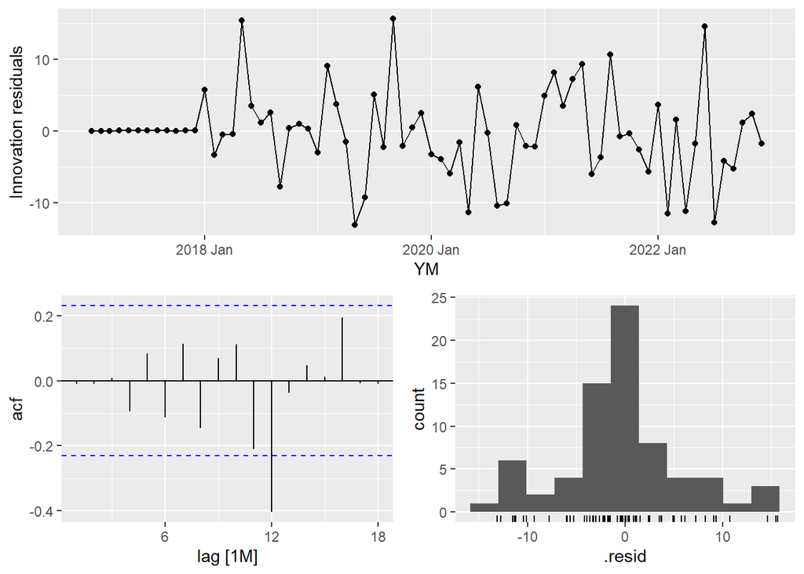

```r
best_mod %>%
  gg_tsresiduals()
```

(ii). We can use the “Ljung-Box Test for Residual Autocorrelation” to check if there is significant autocorrelation left in the residuals at a particular lag.

Ljung-Box test indicates that lag 1 still has residual auto-correlation as p-value < 0.05

```r
lag1 = best_mod %>%
  augment() %>%
  features(.innov, ljung_box, lag = 1, dof = 1)

lag2 = best_mod %>%
  augment() %>%
  features(.innov, ljung_box, lag = 2, dof = 1)

lag3 = best_mod %>%
  augment() %>%
  features(.innov, ljung_box, lag = 3, dof = 1)

lag4 = best_mod %>%
  augment() %>%
  features(.innov, ljung_box, lag = 4, dof = 1)

lag5 = best_mod %>%
  augment() %>%
  features(.innov, ljung_box, lag = 5, dof = 1)
```

```r
table_resid <- data.frame(lag = c(1,2,3,4,5),
                          lb_stat = c(lag1$lb_stat,lag2$lb_stat,lag3$lb_stat,lag4$lb_stat,lag5$lb_stat),
                          pvalue = c(lag1$lb_pvalue,lag2$lb_pvalue,lag3$lb_pvalue,lag4$lb_pvalue,lag5$lb_pvalue))

print(table_resid)
```

```
  lag     lb_stat    pvalue
1   1 0.006686352 0.0000000
2   2 0.015012555 0.9024827
3   3 0.021559323 0.9892782
4   4 0.717363647 0.8691124
5   5 1.275724070 0.8654806
```

As we still see some residual autocorrelation, In order to predict future values, we have now used automated ARIMA tool on the original AQI to find the best model.

Note: We are using original AQI values as we have not performed log/box-cox transformation as it was variance stationary, we will have to apply log/box-cox function as this is not handled by ARIMA internally. Taking lag difference for handling mean stationarity and seasonal difference for handling seasonality is usually handled by ‘d’ and ‘D’ terms in ARIMA.

```r
best_model2 = AQIdata2 %>%
  model(
    fable::ARIMA(value,approximation=F,
    stepwise=F)
  )

best_model2%>%
  report()
```

```
Series: value
Model: ARIMA(1,0,1)(1,1,0)[12]

Coefficients:
          ar1     ma1     sar1
      -0.6521  0.9506  -0.5798
s.e.   0.1324  0.0760   0.1099

sigma^2 estimated as 29.36:  log likelihood=-188.19
AIC=384.39   AICc=385.12   BIC=392.77
```

The output above suggests that ARIMA(1,0,1) with seasonal components(1, 1, 0) is the best fit model. This means that our time series has an auto-regressive and a moving average process. Also, it has a seasonal component as well.

The residual ACF plot doesn’t show any significant lags using this model.

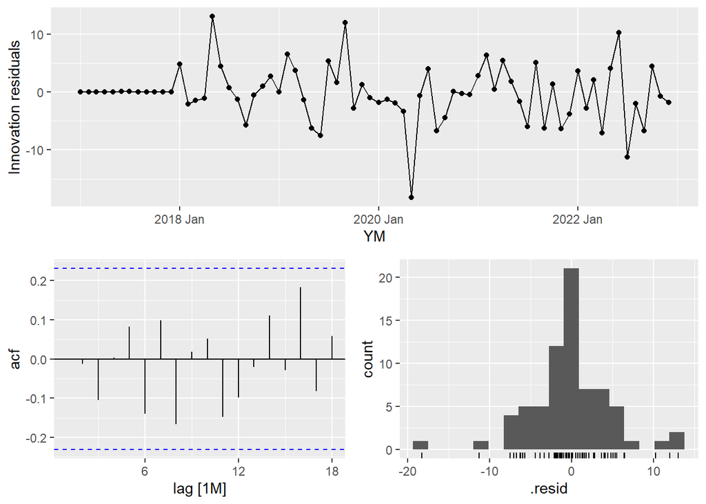

```r
best_model2 %>%
  gg_tsresiduals()
```

The in-sample predicted value tends to follow the original time series trend pretty well with minor difference in scale

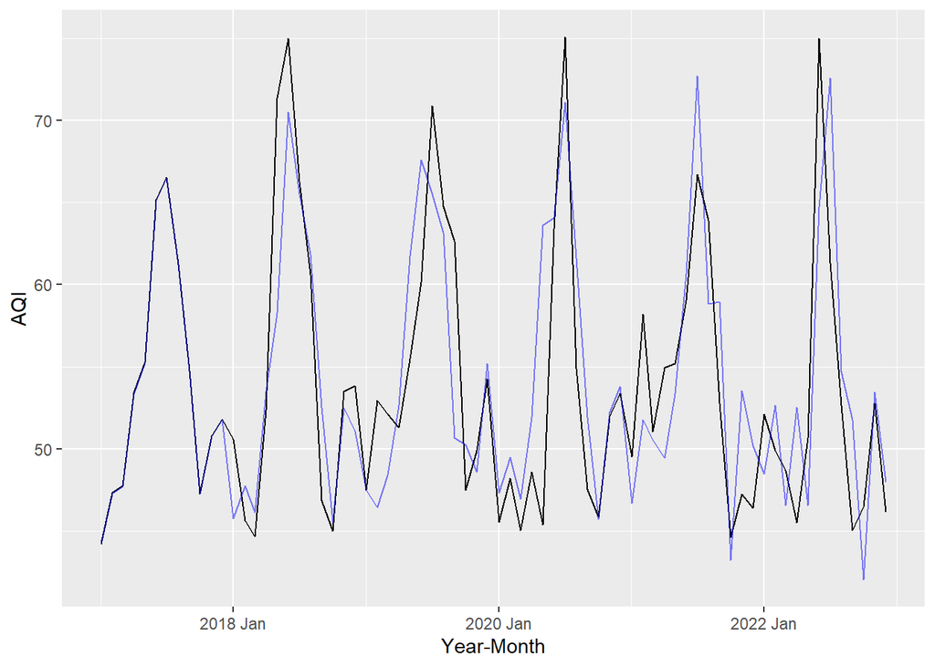

```r
# Get fitted values
fit2 = best_model2 %>%
  augment() %>%
  .$.fitted

ggplot() +
  geom_line(aes(AQIdata2$YM, AQIdata2$value)) +
  geom_line(aes(AQIdata2$YM, fit2), color = "blue", alpha = 0.5) +
  xlab("Year-Month") +
  ylab("AQI")
```

##### The 6-time period forecast:

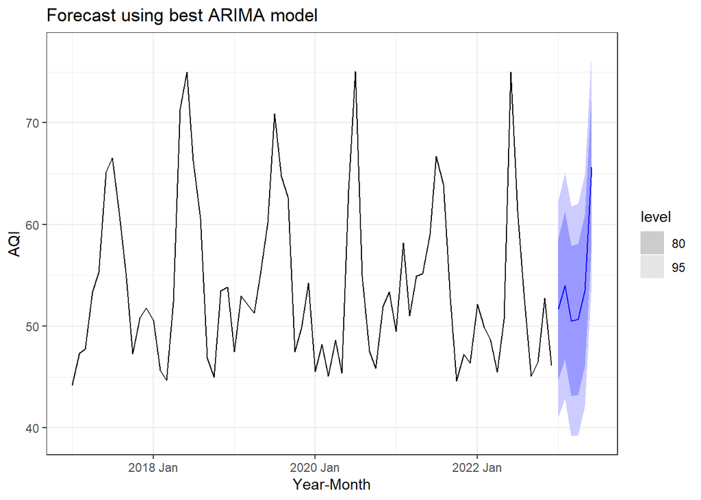

```r
best_model2 %>%
  forecast(h=6) %>%
   autoplot(AQIdata2 %>% bind_rows())+
  theme_bw()+
  labs(title = "Forecast using best ARIMA model",
       y = "AQI",
       x = "Year-Month")
```